# Lab 13 - National Ozone Time Series

GE 509

The objective of this week’s lab is to familiarize yourself with the tools and techniques to do exploratory analyses for time series analysis and to fit a basic Bayesian AR(1) model.

## Part 1: Exploratory analysis

Exploratory analyses are useful to gain a better understanding of the data and how it is structured in order to help with the design of more advanced models and should not be done in place of more careful modeling.

```r
load("data/Ozone.RData")       ## data
```

The Ozoner.Rdata file contains a data table, *ozone*, which contains nationally averaged ozone data for 1980-2008. This data is expressed in terms of the 4th Maximum 8-Hour Average (ppb), which is an odd statistic but one relevant to regulatory criteria.

Let’s begin by plotting the data:

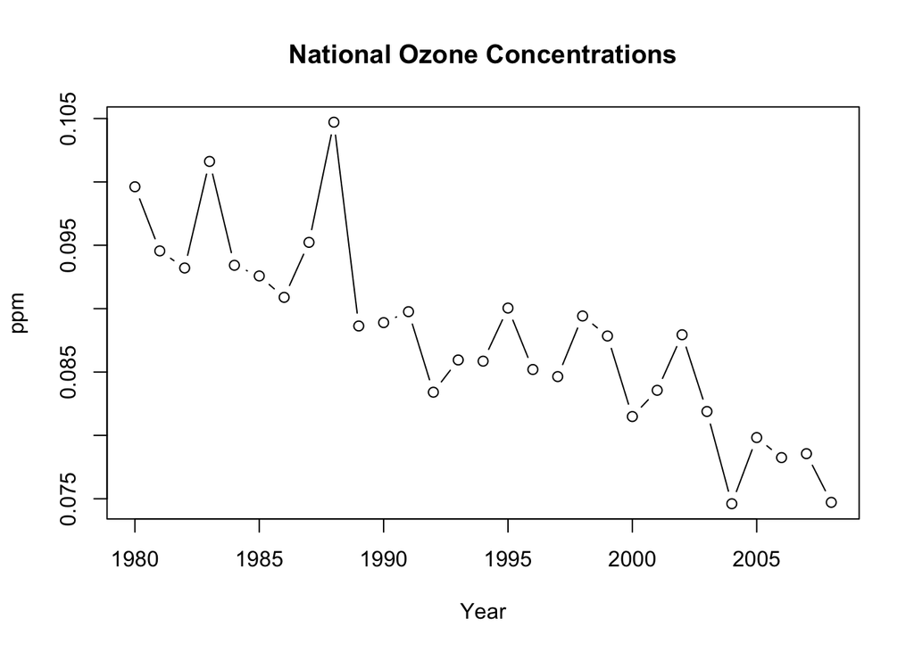

```r
xt <- ts(ozone$Mean,start=1980,end=2008)  ## convert data to a time series object
plot(xt,type='b',ylab="ppm",xlab="Year",main="National Ozone Concentrations")
```

Next let’s look at a couple of approaches for smoothing the data. First lets try a weighted moving average with a window of size 5. This calculates an average value within the window that moves over the time series one point at a time. Recall that to do a weighted moving average in R we use the more general filter function and then specify a vector of weights (aka the kernel) that is symmetric and sums to 1.

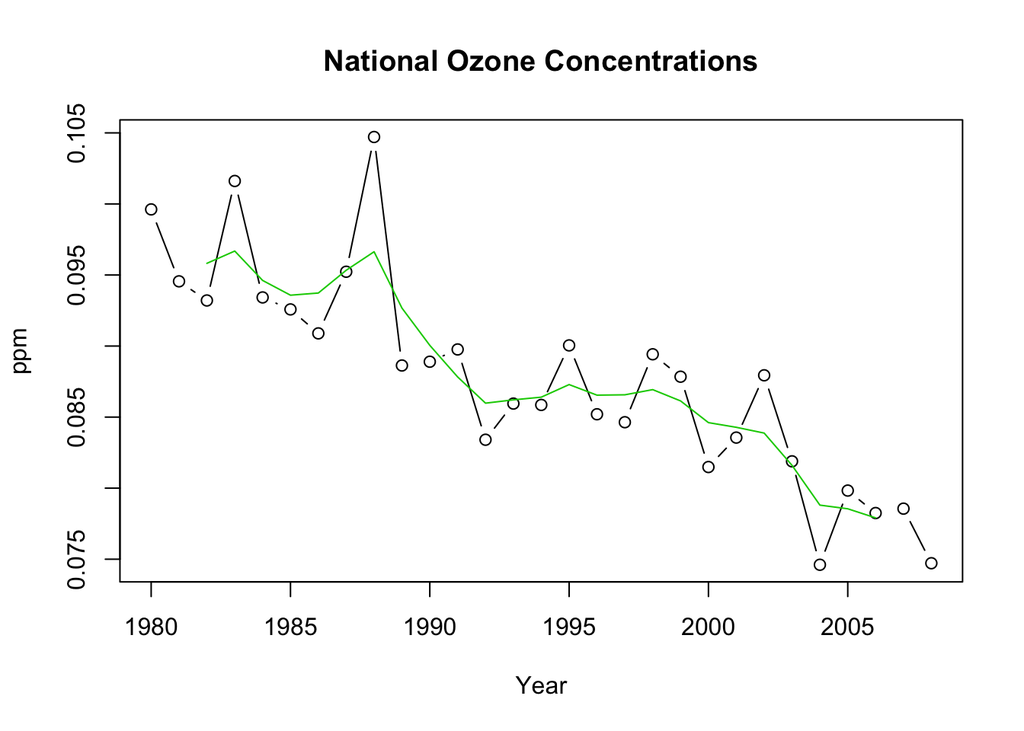

```r
k <- c(0.1,0.2,0.4,0.2,0.1)      ## kernel
fx <- filter(xt,k)               ## weighted moving average
plot(xt,type='b',ylab="ppm",xlab="Year",main="National Ozone Concentrations")
lines(fx,col=3)
```

Second, let’s look at a lowess curve. Recall that a lowess curve also uses a moving window, but instead of an average it calculates a weighted regression model. The second parameter to the lowess, f, is the window size expressed as a fraction of the whole time series. In general, window sizes are much larger with the lowess approach than the moving window because we’re fitting a curve through the points. Feel free to play around with the size of f to see how it affects the smoothness of the curve.

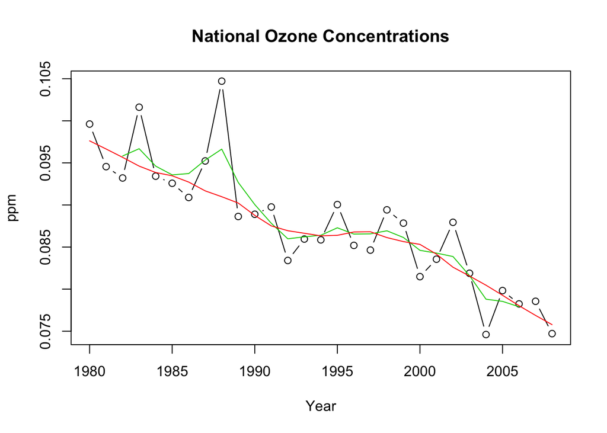

```r
lx <- lowess(xt,f=1/3)
plot(xt,type='b',ylab="ppm",xlab="Year",main="National Ozone Concentrations")
lines(fx,col=3)
lines(lx,col=2)
```

### Lab Report Task 1

1. Include the above time series plot and briefly describe the features of the overall trend in ozone concentrations.
- Overall trend: downward, but seems to increase for one year than go down for 1-3 subsequent years

Now that we’ve estimated the trend in the data we can remove that trend by subtracting the smoothed time series from the raw time series and look at the characteristics of the residuals. Remember that after detrending the time series residuals should meet the assumptions of second-order stationarity—mean zero with homeskedastic variance. For this example lets use the lowess curve as our trend.

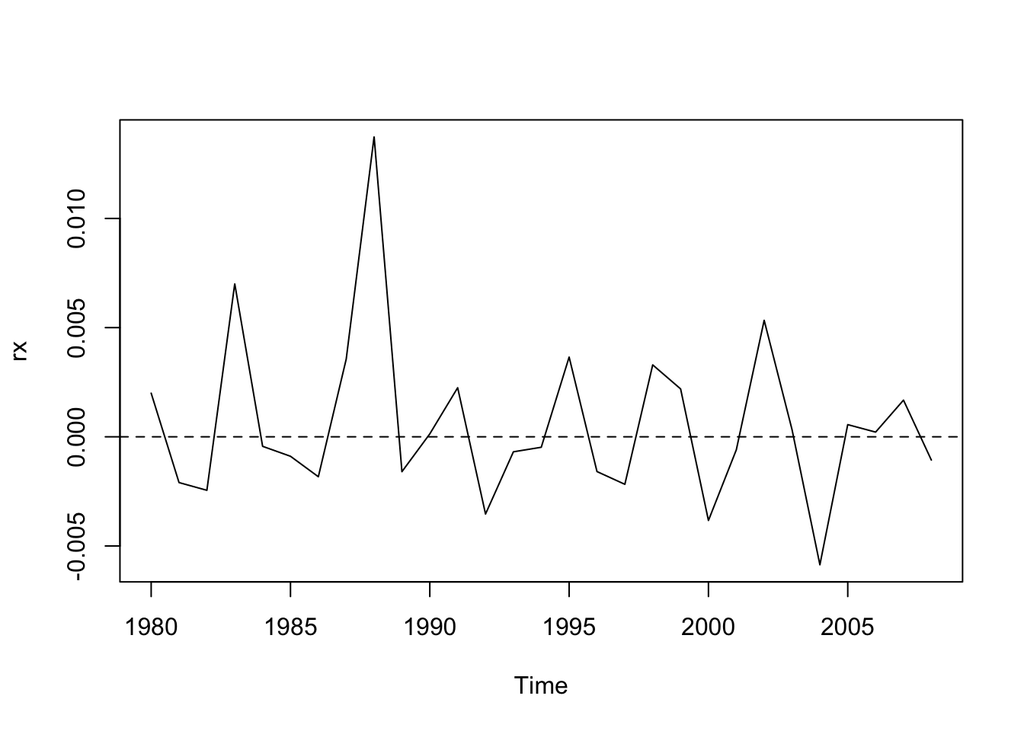

```r
rx = xt - lx$y        ## residuals around lowess curve
plot(rx)              ## check for homoskedasticity
abline(h=0,lty=2)
```

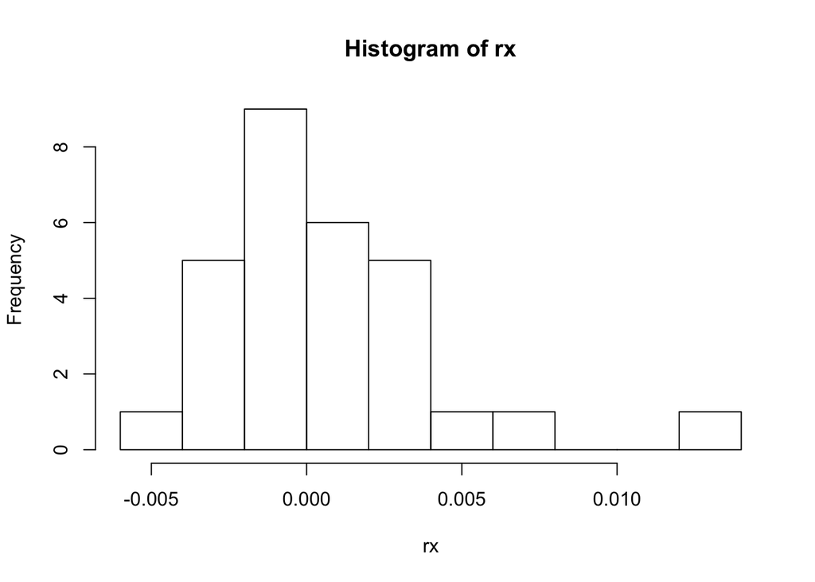

```r
hist(rx,10)              ## check for a normal distribution with mean=zero
```

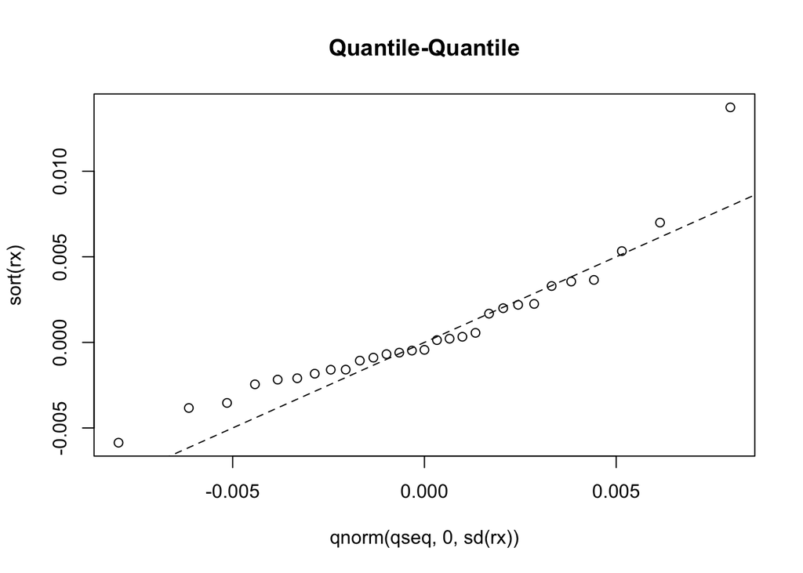

```r
## Quantile-Quantile plot (by hand)
n = length(rx)
qseq = seq(0.5/n,length=n,by=1/n)
plot(qnorm(qseq,0,sd(rx)),sort(rx),main="Quantile-Quantile")
abline(0,1,lty=2)
```

As an alternative to detrending we can also look at the difference series for the time series. Differencing a time series can also be used to remove the trend. In addition, we often conceive of our process models in terms of changes over time rather than absolute magnitudes.

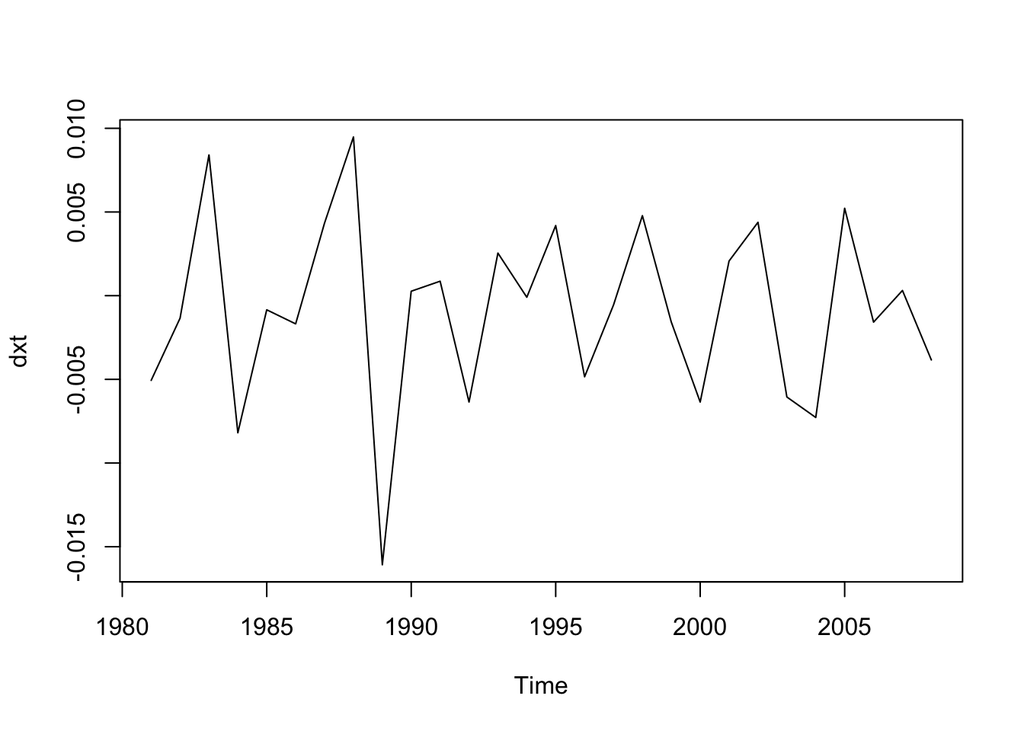

```r
dxt = diff(xt)
plot(dxt)
```

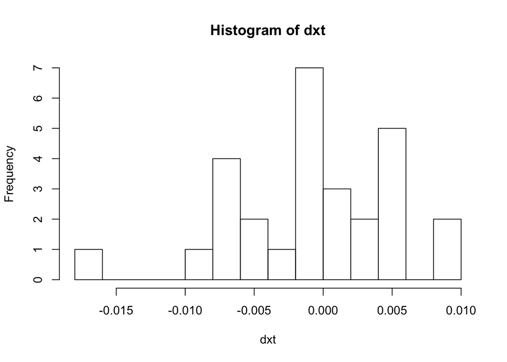

```r
hist(dxt,10)
```

### Lab Report Task 2

2. Does the detrended data meet the assumptions of second order stationarity? Why or why not?
- The detrended data mostly fits the assumptions of second order stationarity. The residual mean is roughly zero, with a single point that skews the mean and makes the variance appear heteroskedastic. Because this is only driven by one point, I would say that it is close enough to the assumptions that we can use it for fitting our model.
3. Does the first-difference time series meet the assumptions of second order stationarity? Why or why not?
- Again, these residuals would meet the stationarity assumptions if one point was removed, so I would consider this to meet the stationarity assumptions.

Next let’s evaluate the autocorrelation and partial autocorrelation in the time series. You’ve seen ACFs quite frequently in MCMCs so you should be fairly familiar with their interpretation. A partial ACF is a variant of ACF where at each lag we’re looking at the autocorrelation after having accounted for the autocorrelation at shorter lags. The number of significant lags in the partial ACF can be a very useful guide to the number of lags that should be included when modeling the system, for example with an ARIMA model.

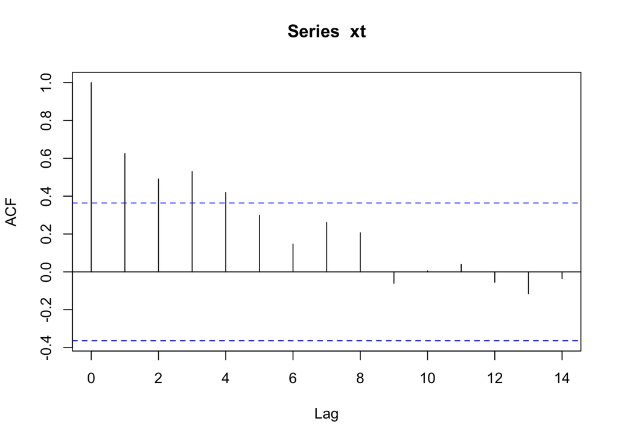

```r
acf(xt)    ## ACF on the original time series
```

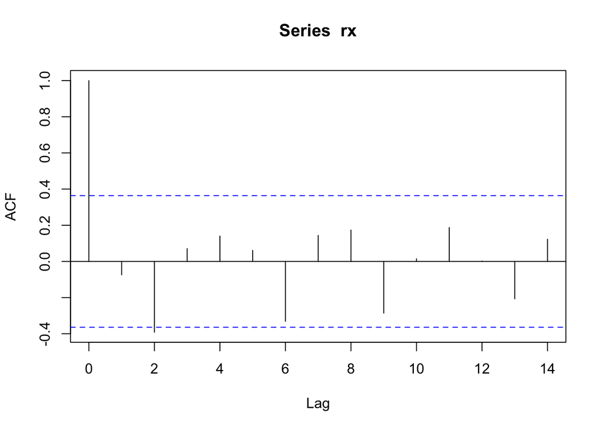

```r
acf(rx)    ## ACF on the detrended data
```

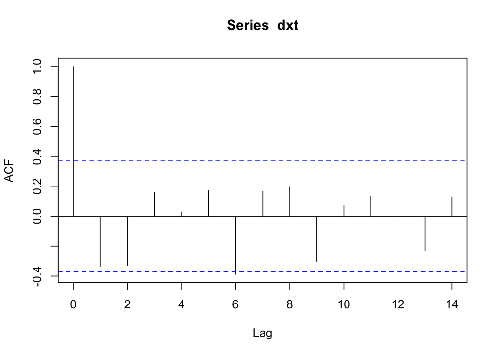

```r
acf(dxt)   ## ACF on the first difference series
```

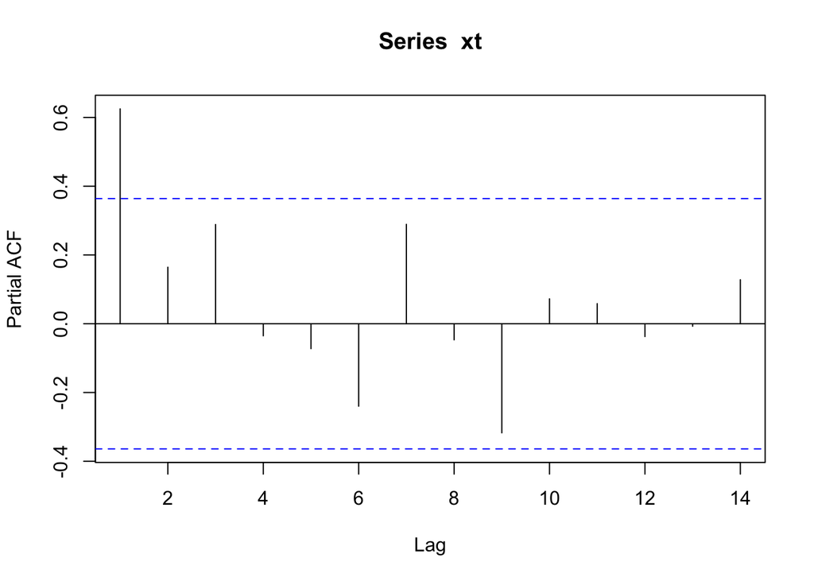

```r
pacf(xt)   ## Partial ACF of the time series
```

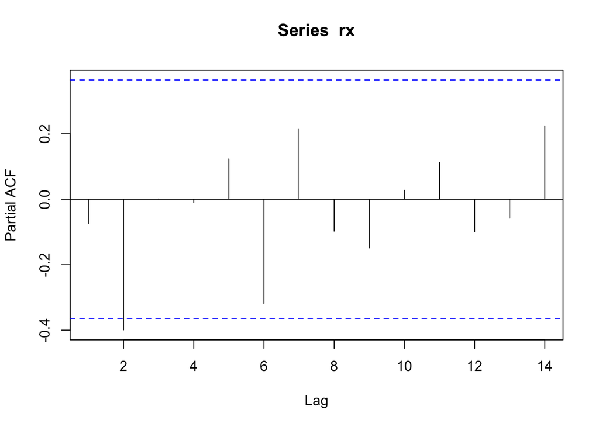

```r
pacf(rx)   ## Partial ACF of the detrended data
```

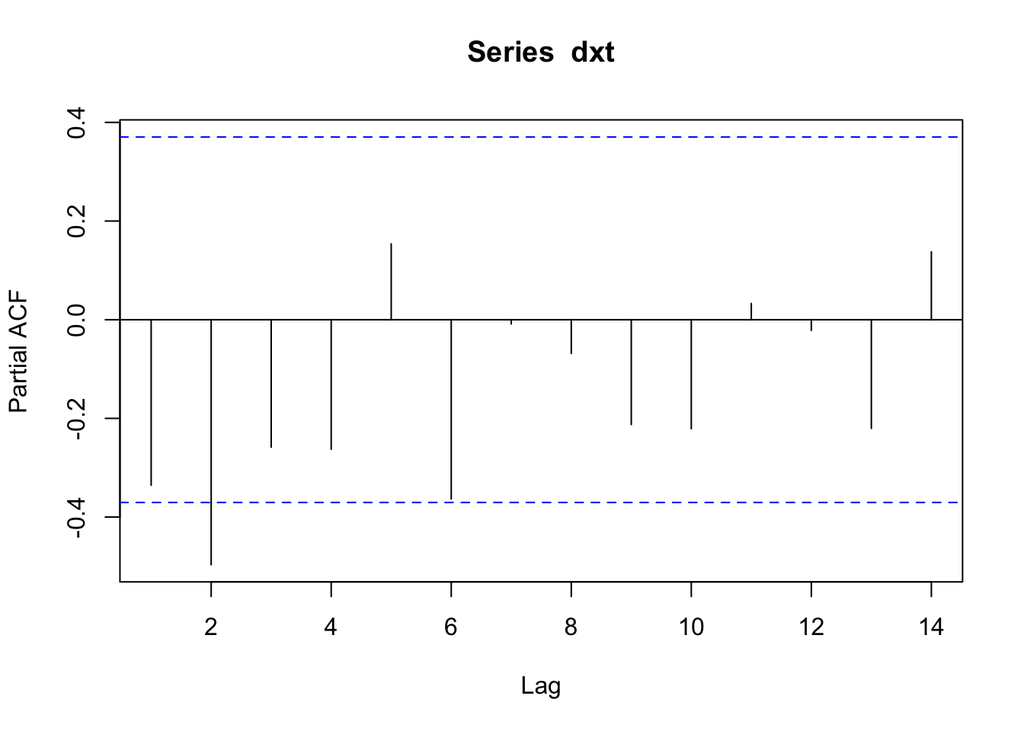

```r
pacf(dxt)  ## Partial ACF of the first differences
```

## Part 2: ARIMA (MLE)

Now that we’ve calculated a number of diagnostics, let’s explore how me might structure our time-series model. The flow chart below serves as an aid to help suggest what order of the ARIMA(p,d,q) model is likely to be a good description of the data. You should have already calculated all of the plots necessary in order to work through this flowchart. As a reminder, the ARIMA(p,d,q) is the general case of the autoregressive model, the moving average model, and the integrated model. The degree of each of these models are such that an AR(p) model and a MA(q) model are ones that have p or q lags respectively. An I(d) model is one where we’re modeling a data set that has been differenced d times. Therefore, as examples, an AR(1) model is equivalent to an ARIMA(1,0,0) model, and an MA(1) model on the first-differences of a time series would be an ARIMA(0,1,1).

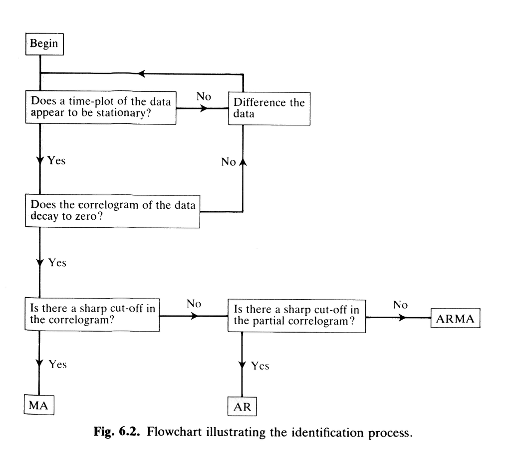

ARIMA Flow Chart

### Lab Report Task 3 4. Based on the diagnostics you have already performed, what ARIMA model is likely to perform best? What orders should p, d, and q be? Why? Should you fit the model to xt or rx?

5. Fit the arima model you proposed using the function arima:

```r
#arima(xt,c(p,d,q))

aic1 <- arima(rx,c(1,0,0))
aic2 <- arima(rx,c(0,1,0))
aic3 <- arima(rx,c(0,0,1))
aic4 <- arima(rx,c(1,1,1))
aic5 <- arima(xt,c(1,0,0))
aic6 <- arima(xt,c(0,2,0))

df <- cbind("Model" = as.character(c(aic1$call, aic2$call, aic3$call, aic4$call, aic5$call, aic6$call)),
                 "AIC" = c(aic1$aic, aic2$aic, aic3$aic, aic4$aic, aic5$aic, aic6$aic))

print(df)
```

```
##      Model                               AIC
## [1,] "arima(x = rx, order = c(1, 0, 0))" "-236.51943752886"
## [2,] "arima(x = rx, order = c(0, 1, 0))" "-209.766255142534"
## [3,] "arima(x = rx, order = c(0, 0, 1))" "-236.944190351403"
## [4,] "arima(x = rx, order = c(1, 1, 1))" "-223.700548251881"
## [5,] "arima(x = xt, order = c(1, 0, 0))" "-215.640838870532"
## [6,] "arima(x = xt, order = c(0, 2, 0))" "-175.814047238012"
```

```r
ar(xt)
```

```
##
## Call:
## ar(x = xt)
##
## Coefficients:
##      1
## 0.6249
##
## Order selected 1  sigma^2 estimated as  3.489e-05
```

```r
ar(rx)
```

```
##
## Call:
## ar(x = rx)
##
## Coefficients:
##       1        2
## -0.1038  -0.3991
##
## Order selected 2  sigma^2 estimated as  1.281e-05
```

```r
# By running ar(xt) and ar(rx), we see that the detrended data should have an order 2,
# and the un-detrended data should have order 1
aic7 <- arima(rx, c(2,0,0))
print(aic7)
```

```
##
## Call:
## arima(x = rx, order = c(2, 0, 0))
##
## Coefficients:
##           ar1      ar2  intercept
##       -0.0970  -0.3842      6e-04
## s.e.   0.1695   0.1652      5e-04
##
## sigma^2 estimated as 1.144e-05:  log likelihood = 123.68,  aic = -239.36
```

Then propose alternative models that are similar to the one you fit (e.g. increase or decrease orders by 1). Based on AIC scores what model provides the best fit? Provide a table of models you tried and their AIC scores.

- The best model I tried had an AIC of -236: ARIMA(0, 0, 1). By running the ar() commands, however, I saw that a lower AIC (-239) was achievable with a structure of ARIMA(2,0,0).

# Part 3: Bayesian AR(1)

For the last part of this lab we will explore how to add autocorrelated error to a data model in a Bayesian context. Looking back to our first exploratory plots on detrending, we can see that the decline in ozone is approximately linear

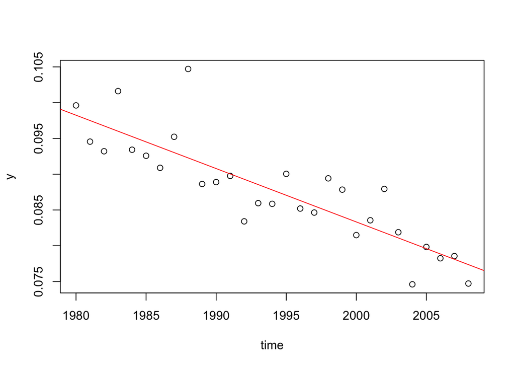

```r
data <- list(time = 1980:2008,y = ozone$Mean)
MLE.fit <- lm(y~time,data)
plot(y~time,data)
abline(MLE.fit,col=2)
```

However, if we wanted to fit a Bayesian linear model to this trend we might want to account for the autocorrelation in the data. Conceptually, to do so we’d want to switch our standard Gaussian likelihood with independent residuals to a multivariate Gaussian likelihood with a covariance matrix.

```
    y ~ dmnorm(mu,SIGMA)
```

Note in this case that y and mu are both vectors and we don’t need a loop over `y[i]` because we’re fitting all the y’s at once. We also need to calculate `SIGMA` within our JAGS code

```
  SIGMA <- inverse((1/sigma)/(1-rho^2)*rho^H)
```

where H is the distance matrix described in lecture

```r
data$H = as.matrix(dist(1:nrow(ozone),diag = TRUE,upper = TRUE))
data$H
```

```
##     1  2  3  4  5  6  7  8  9 10 11 12 13 14 15 16 17 18 19 20 21 22 23 24
## 1   0  1  2  3  4  5  6  7  8  9 10 11 12 13 14 15 16 17 18 19 20 21 22 23
## 2   1  0  1  2  3  4  5  6  7  8  9 10 11 12 13 14 15 16 17 18 19 20 21 22
## 3   2  1  0  1  2  3  4  5  6  7  8  9 10 11 12 13 14 15 16 17 18 19 20 21
## 4   3  2  1  0  1  2  3  4  5  6  7  8  9 10 11 12 13 14 15 16 17 18 19 20
## 5   4  3  2  1  0  1  2  3  4  5  6  7  8  9 10 11 12 13 14 15 16 17 18 19
## 6   5  4  3  2  1  0  1  2  3  4  5  6  7  8  9 10 11 12 13 14 15 16 17 18
## 7   6  5  4  3  2  1  0  1  2  3  4  5  6  7  8  9 10 11 12 13 14 15 16 17
## 8   7  6  5  4  3  2  1  0  1  2  3  4  5  6  7  8  9 10 11 12 13 14 15 16
## 9   8  7  6  5  4  3  2  1  0  1  2  3  4  5  6  7  8  9 10 11 12 13 14 15
## 10  9  8  7  6  5  4  3  2  1  0  1  2  3  4  5  6  7  8  9 10 11 12 13 14
## 11 10  9  8  7  6  5  4  3  2  1  0  1  2  3  4  5  6  7  8  9 10 11 12 13
## 12 11 10  9  8  7  6  5  4  3  2  1  0  1  2  3  4  5  6  7  8  9 10 11 12
## 13 12 11 10  9  8  7  6  5  4  3  2  1  0  1  2  3  4  5  6  7  8  9 10 11
## 14 13 12 11 10  9  8  7  6  5  4  3  2  1  0  1  2  3  4  5  6  7  8  9 10
```

[output cut: 45 more lines]

and (1/sigma) converts the precision to a variance and `inverse` translates the covariance matrix into the precision matrix that JAGS wants. We also need to add a prior on rho

```
  rho   ~ dunif(-1,1)
```

### Lab Report Task 4

6. Fit the AR(1) linear model described above to the ozone data. You can do this either by modifying the basic univariate regression model from Lab 6, adding the components described above, or by modifying the linear repeated measures model from Lesson 33 by removing the for loop and changing `X[i,]` to a single vector `time`, and `g[i,]` to a single vector `y`. Report **and interpret** summary and convergence statistics and density plots for **all parameters**. You do not need to report stats for intermediate calculations (e.g. mu).

Hints/warnings: * This model can be slow to converge * The units on the ozone data are small (and thus variance priors should be given careful thought). * A dmvnorm prior on beta will result in conjugacy with the dmvnorm likelihood, while separate dnorm priors on beta[1] and beta[2] will not.

```r
library(rjags)
mod <- "model{

 beta ~ dmnorm(b0,Vb)
 sigma ~ dgamma(0.01,0.01)
 rho ~ dunif(-1,1)
 SIGMA <- inverse(1/sigma/(1-rho^2)*rho^H)

   mu <- beta[1]+beta[2]*time
   y ~ dmnorm(mu,SIGMA)
}"

data$b0 <- as.vector(c(0,0))      ## regression beta means
data$Vb <- solve(diag(10000,2))   ## regression beta precisions

j.model   <- jags.model (file = textConnection(mod),
                             data = data,
#                             inits = inits,
                             n.chains = 3)
```

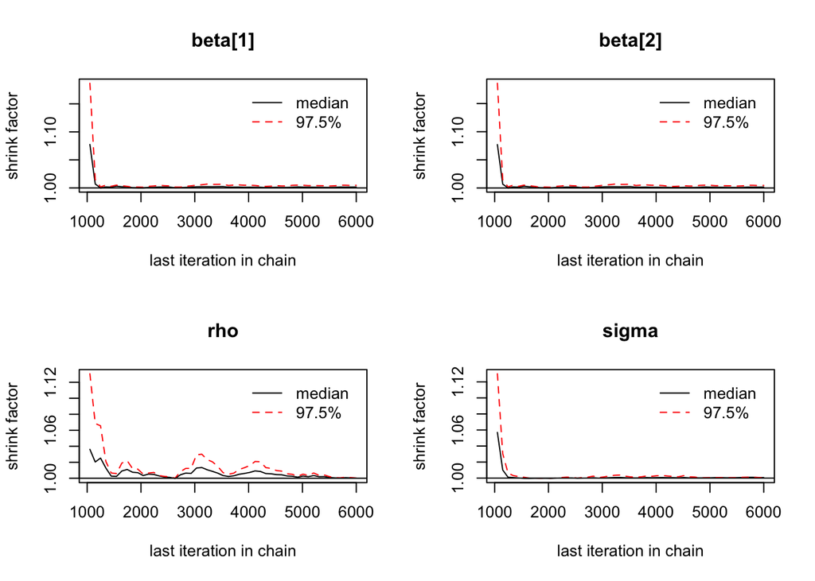

```r
var.out   <- coda.samples (model = j.model,
                            variable.names = c("beta","rho","sigma"),
                                n.iter = 5000)

gelman.plot(var.out)
```

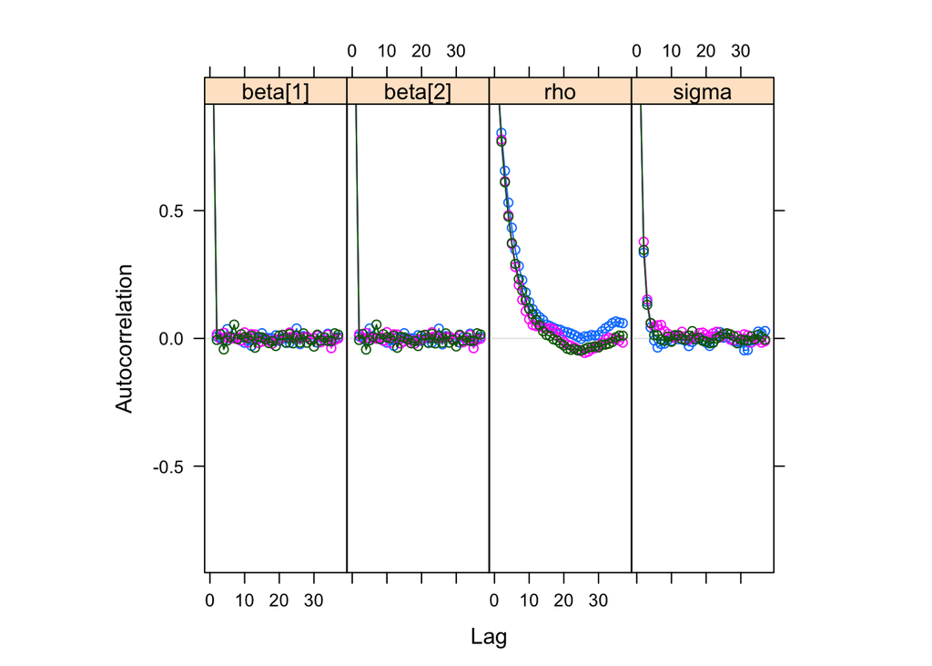

```r
acfplot(var.out)
```

[figure not shown]

```r
jags.burn <- window(var.out,start=3000)  ## remove burn-in
plot(jags.burn)                             ## check diagnostics post burn-in
```